# Part II - "Understanding Trip Duration and User Types Trends in a Bike Sharing System"

## Investigation Overview

> In this project i did some cleaning on the data to apply the skills i learned in visualizing different variable and their relations. In the fordgobike dataset, my goal was to find relations between variables and how they would affect each other, my main focus was on trip duration and user types, i used other variables to support in my analyzing process such as (member gender, birth year , shared programs). I used different kind of plots to show my work and communicate through it with other people, i used histograms, countplot, boxplot, violinplot, and facetgrids to show my findings by plotting with one, two, and 4 variables.

## Dataset Overview and Executive Summary

**Introduction**

> This dataset has around 183,000 entries and 16 variables, start and end of the trip aswell the trip duration in seconds. It contains data about the station details, station id, name, longitude and latitude for the start and end station, bike id, user type, member details such as birth year and gender and finally 'bike_share_for_all_trip' specifying whether the trip was part of a bike share program.

**Key insights**

> Throgh the visualizations across univariate, bivariate, and multivariate we found that:

> Most of the users are subscribers.

> Subscribers usually tend to take shorter trips while customers take longer trips.

> Customers don't attend shared programs

```python
# load in the dataset into a pandas dataframe
df = pd.read_csv("cleaned_data.csv")
```

## (Visualization 1)

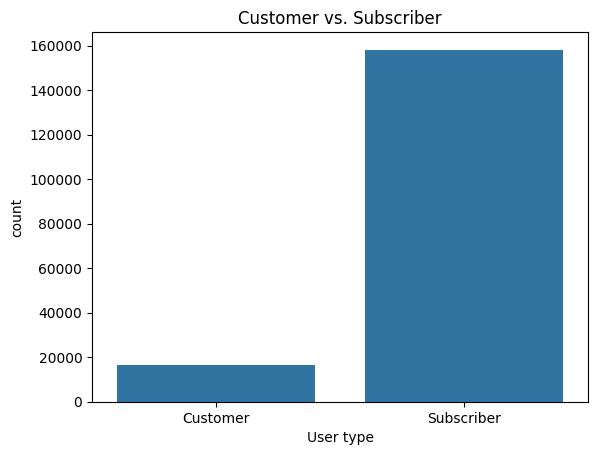

```python
sns.countplot(data= df, x = 'user_type')
plt.xlabel('User type')
plt.title("Customer vs. Subscriber")
```

## (Visualization 2)

In the key insights i mentioned that customers usually tend to take longer trips than subscribers, which i would be showing in the next plot.

```
(0.0, 5000.0)
```

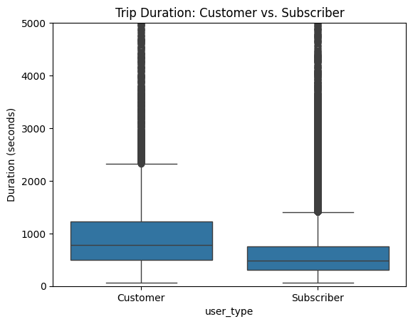

```python
sns.boxplot(data=df, x="user_type", y="duration_sec")
plt.title("Trip Duration: Customer vs. Subscriber")
plt.ylabel("Duration (seconds)")
plt.ylim(0,5000)
```

It could be that customers More likely tourists or leisure riders, who take longer rides for sightseeing, fun .While subscribers use bikes to commute from one station to other on a regular basis.

## (Visualization 3)

In this plot we would see what user type attend shared programs and what age usually take longer trip durations

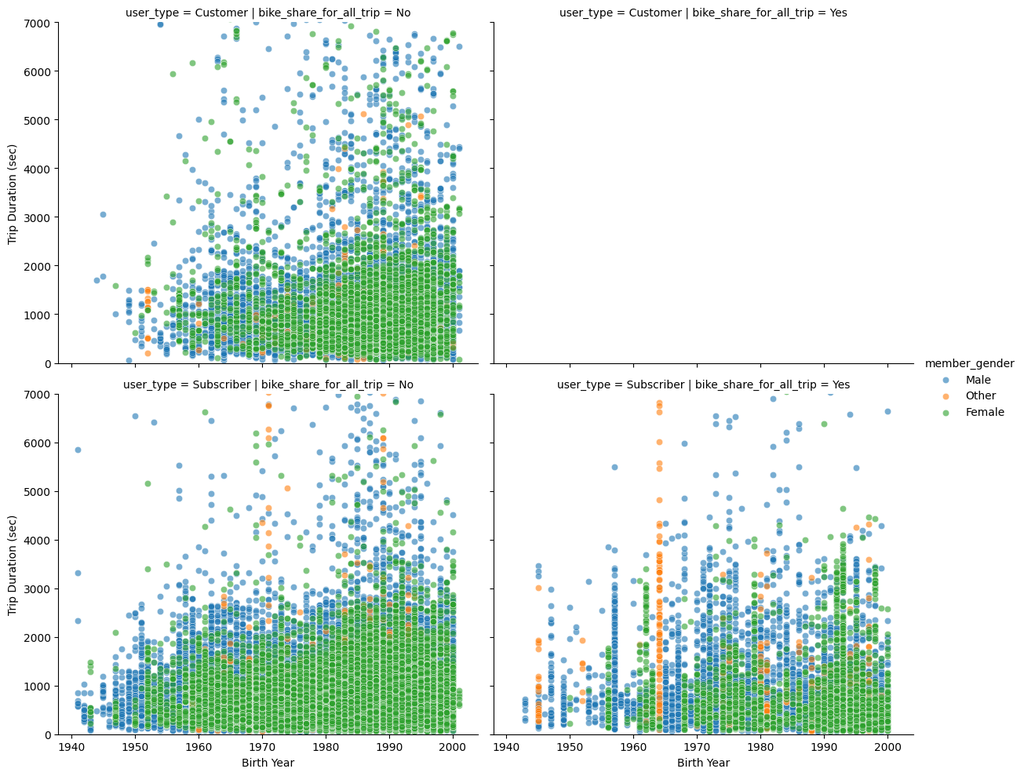

```python
g = sns.FacetGrid(df, col='bike_share_for_all_trip', row='user_type', hue='member_gender', height=5, aspect=1.2)
g.map_dataframe(sns.scatterplot, x='member_birth_year', y='duration_sec', alpha=0.6)

g.set_axis_labels("Birth Year", "Trip Duration (sec)")
g.add_legend()
plt.ylim(0,7000)
plt.show()
```

We can notice that there is no data of customers being in a shared program.